# *Relatório 2 PEL 201*

**Aluno**:Juliano Alves de Oliveira. **R.A**:1173095

**Linguagem utilizada**=Python

# Bubble Sort

O algoritmo **Bubble sort** é uma algoritmo de ordenação simples. O seu funcionamento se dá da seguinte forma:

1. Percorre-se o vetor de entrada inteiro sempre comparando-se de dois em dois(Comparação entre o elemento **i** e **i+1** os valores do vetor de entrada
2. Caso o valor do **i+1** seja menor que o valor de **i** os valores são alternados, sendo o novo valor de **i** igual ao **i+1** e vice-versa este processo ocorre até o elemento **n-1** .
3. Ao fim desta primeira interação o maior elemento do vetor estará na última posição.
4. O processo continua até a execução **n-1** do algoritmo base que percorre todo o vetor.

[figure not shown]

fonte:https://pt.wikipedia.org/wiki/Bubble_sort

```python
def bubbleSort(alist):
    for passnum in range(len(alist)-1,0,-1):
        for i in range(passnum):
            if alist[i]>alist[i+1]:
                temp = alist[i]
                alist[i] = alist[i+1]
                alist[i+1] = temp
```

# Quick Sort

O algoritmo de **Quick Sort** adota a estratégia de divisão e conquista. A idéia por de trás do algoritmo pode ser explicada da seguinte forma:

1. Elege-se um elemento pivô do vetor de entrada. Neste caso existe duas variações um pivô fixo (primeiro elemento) ou um pivô randômico, ou seja, qualquer posição do vetor. Essas variações se dão pelo motivo de um possível caso de vetor de entrada ordenado, que acaba prejudicando o método de pivô fixo.
2. Após essa eleição, o vetor de entrada é rearranjado de tal forma que os elementos menores que o pivô são postos antes do pivô e os maiores após o pivô, depois disso existiram duas sublistas (partições)
3. Estas partições são passadas, de forma recursiva, para o algoritmo **Quick sort** e ordenadas da mesma forma.
4. Este processo continua até que o vetor de entrada das chamadas recursivas tenha tamanho $1$.

[figure not shown]

fonte:https://pt.wikipedia.org/wiki/Quicksort

# Quick Sort First Element pivot

```python
def quickSortPivotFirstElement(alist):
   quickSortHelperPivotFirstElement(alist,0,len(alist)-1)

def quickSortHelperPivotFirstElement(alist,first,last):
   if first<last:

       splitpoint = partitionPivotFirstElement(alist,first,last)

       quickSortHelperPivotFirstElement(alist,first,splitpoint-1)
       quickSortHelperPivotFirstElement(alist,splitpoint+1,last)


def partitionPivotFirstElement(alist,first,last):
   pivotvalue = alist[first]

   leftmark = first+1
   rightmark = last

   done = False
   while not done:

       while leftmark <= rightmark and alist[leftmark] <= pivotvalue:
           leftmark = leftmark + 1

       while alist[rightmark] >= pivotvalue and rightmark >= leftmark:
           rightmark = rightmark -1

       if rightmark < leftmark:
           done = True
       else:
           temp = alist[leftmark]
           alist[leftmark] = alist[rightmark]
           alist[rightmark] = temp

   temp = alist[first]
   alist[first] = alist[rightmark]
   alist[rightmark] = temp


   return rightmark
```

# Quick Sort Random Element pivot

```python
def quickSortPivotRandomElement(alist):
   quickSortHelperPivotRandomElement(alist,0,len(alist)-1)

def quickSortHelperPivotRandomElement(alist,first,last):
   if first<last:

       splitpoint = partitionPivotRandomElement(alist,first,last)

       quickSortHelperPivotRandomElement(alist,first,splitpoint-1)
       quickSortHelperPivotRandomElement(alist,splitpoint+1,last)


def partitionPivotRandomElement(alist,first,last):
   pivotvalue = alist[rnd.randrange(first,last+1,2)] # adionando 1 ao último elemento para garantir a inclusão do valor na lista de valores random

   leftmark = first+1
   rightmark = last

   done = False
   while not done:

       while leftmark <= rightmark and alist[leftmark] <= pivotvalue:
           leftmark = leftmark + 1

       while alist[rightmark] >= pivotvalue and rightmark >= leftmark:
           rightmark = rightmark -1

       if rightmark < leftmark:
           done = True
       else:
           temp = alist[leftmark]
           alist[leftmark] = alist[rightmark]
           alist[rightmark] = temp

   temp = alist[first]
   alist[first] = alist[rightmark]
   alist[rightmark] = temp


   return rightmark
```

# Funções auxiliares

```python
import random as rnd
import numpy as np
import time
import timeit
%matplotlib inline
```

```python
def generate_random_vector(size):
    return np.random.randint(10*size, size=(1, size))
```

# Teste

```python
result_booble = []
result_quick_firstpivot = []
result_quick_randompivot = []
x_vector=[]
for a in range(100000,100100000,100000):
    alist = generate_random_vector(a)
    x_vector.append(a)
    res = %timeit -n100000 -q -o bubbleSort(alist)
    result_booble.append(res.average)
    res = %timeit -n100000 -q -o quickSortPivotFirstElement(alist)
    result_quick_firstpivot.append(res.average)
    res = %timeit -n100000 -q -o quickSortPivotRandomElement(alist)
    result_quick_randompivot.append(res.average)
```

# Resultado

## modo interativo

```python
import plotly.offline as offline
import plotly.plotly as py
from plotly.offline import download_plotlyjs, init_notebook_mode, plot, iplot
from plotly.graph_objs import *
import cufflinks as cf
import math

offline.init_notebook_mode()
offline.iplot({'data':[{"y": np.array(result_booble).transpose(),"x": np.array(x_vector).transpose(),'name':'Bubble Sort'},
                       {"y": np.array(result_quick_firstpivot).transpose(),"x": np.array(x_vector).transpose(),'name':'Quick Sort First Element Pivot'},
                       {"y": np.array(result_quick_randompivot).transpose(),"x": np.array(x_vector).transpose(),'name':'Quick Sort Random Element Pivot'}],
               'layout':{'title':'Comparação Bubble Sort vs Quick Sort Pivot First Element vs Quick Sort Pivot Random Element','xaxis':{'title':'Número de elementos vetor (n)'},
                         'yaxis':{'title':'Tempo de execução[s]'}}})
```

[interactive chart not shown]

# modo offline

```python
import matplotlib.pyplot as plt
```

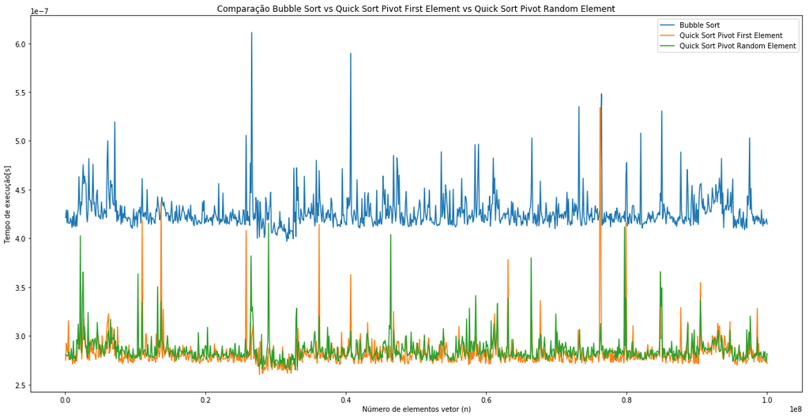

```python
plt.figure(figsize=(20,10))
Bubblelg,=plt.plot(np.array(x_vector).transpose(),np.array(result_booble).transpose(),label='Bubble Sort')
QuikFixlg,=plt.plot(np.array(x_vector).transpose(),np.array(result_quick_firstpivot).transpose(),label='Quick Sort Pivot First Element')
QuikRndlg,=plt.plot(np.array(x_vector).transpose(),np.array(result_quick_randompivot).transpose(),label='Quick Sort Pivot Random Element')
plt.legend(handles=[Bubblelg, QuikFixlg,QuikRndlg])
plt.title("Comparação Bubble Sort vs Quick Sort Pivot First Element vs Quick Sort Pivot Random Element")
plt.xlabel('Número de elementos vetor (n)')
plt.ylabel('Tempo de execução[s]')
plt.show()
```

# Conclusões

- Vetor ordenado crescente

```python
alist = np.arange(1000)
```

```python
booble_crescente = []
result_quick_firstpivot_crescente = []
result_quick_randompivot_crescente = []

res = %timeit -n1 -q -o bubbleSort(alist)
booble_crescente.append(res.average)
res = %timeit -n1 -q -o quickSortPivotFirstElement(alist)
result_quick_firstpivot_crescente.append(res.average)
res = %timeit -n10 -q -o quickSortPivotRandomElement(alist)
result_quick_randompivot_crescente.append(res.average)
```

```python
import plotly.plotly as py
import plotly.graph_objs as go

data = [go.Bar(
            x=['Bubble', 'Quick Sort Fixed Pivot', 'Quick Sort Random Pivot'],
            y=[booble_crescente[0], result_quick_firstpivot_crescente[0], result_quick_randompivot_crescente[0]]

    )]

offline.iplot(data, filename='basic-bar')
```

[interactive chart not shown]

### Resultado offline

[figure not shown]

- Vetor decrescente

```python
alist_decre = np.arange(1000,0,-1)
```

```python
res = %timeit -n1 -q -o bubbleSort(alist_decre)
bubble_decrescente = res.average
res = %timeit -n1 -q -o quickSortPivotFirstElement(alist_decre)
result_quick_firstpivot_decrescente = res.average
res = %timeit -n10 -q -o quickSortPivotRandomElement(alist_decre)
result_quick_randompivot_decrescente = res.average
```

```python
data = [go.Bar(
            x=['Bubble', 'Quick Sort Fixed Pivot', 'Quick Sort Random Pivot'],
            y=[bubble_decrescente, result_quick_firstpivot_decrescente, result_quick_randompivot_decrescente]

    )]

offline.iplot(data, filename='basic-bar')
```

[interactive chart not shown]

### Resultado offline

[figure not shown]

Os resultados obtidos para os vetores gerados dinamicamente, mostram que o algoritmo **Bubble sort** realmente é menos performatico em relação ao **Quick Sort** em ambos os casos (pivô fixo e variado). Nos resultados obtidos para vetores já ordenados, crescente e decrescente, o algoritmo **Bubble sort** continua sendo o menos performatico, porém o algoritmo com o pivô randomico é melhor do que o que tem pivô fixo, pois no caso de pivô fixo, temos o pior caso para a estratégia do **Quick Sort**.